# **Ejercicios 06 - Estadistica Computacional (13311)**

## **Parte I: Ejemplo de uso de la prueba z con una cola**

*“Se desea contrastar con un nivel de significación del 5 % la hipótesis de que la talla media de los hombres de 18 o más años de un país es igual o mayor a 175. Suponiendo que la desviación típica de las tallas en la población vale 4, contraste dicha hipótesis frente a la alternativa de que es menor, con una muestra de n=15 hombres seleccionados al azar, con una media muestral de 173.47.”*

### **a) Graficando la distribución de probabildad y declaración de hipótesis:**

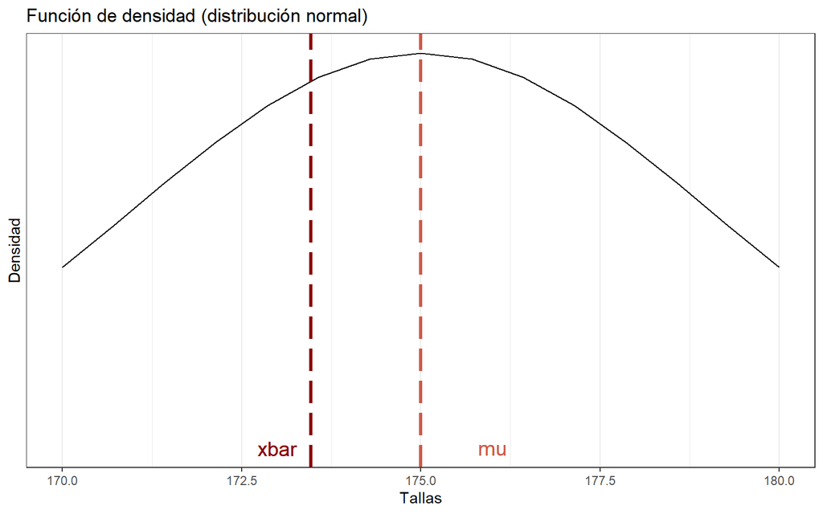

```r
# Grafico
library("ggplot2")
grafico_densidad = ggplot(data = data.frame(x = c(170, 180)), aes(x)) +
  stat_function(fun = dnorm, n = 15, args = list(mean =175, sd = 4)) + ylab("") +
  scale_y_continuous(breaks = NULL) + xlab("Tallas") + ylab("Densidad") + ggtitle("Función de densidad (distribución normal)") + theme_bw() +
  geom_vline(xintercept = 173.47,cex=1.2,colour ="darkred",linetype="longdash") + geom_text(aes(x=173, label="xbar", y=0.0), colour ="darkred",size=5) + geom_vline(xintercept = 175,cex=1.2,colour ="coral3",linetype="longdash") + geom_text(aes(x=176, label="mu", y=0.00001), colour ="coral3",size=5)

grafico_densidad
```

- **La hipótesis nula es:**
  $$H_0: \mu \geq 175$$
- **La hipótesis alternativa es:**
  $$H_A: \mu < 175$$

### **b) Calculo de z:**

```r
# Datos
n = 15
mu = 175
x_bar = 173.47
sigma = 4
z = (x_bar-mu)/(sigma/sqrt(n))

#Confianza
alfa = 0.05 # Nivel de significancia
confianza = 1-alfa
z_alfa = qnorm(alfa)
z
```

```
## [1] -1.481416
```

```r
z_alfa
```

```
## [1] -1.644854
```

### **c) Grafica de lo obtenido y respuesta final:**

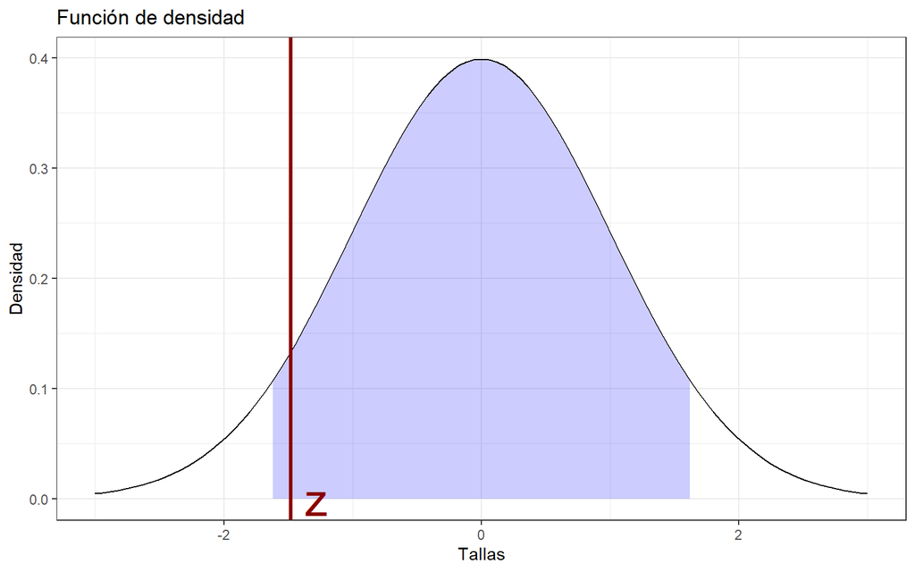

```r
# Grafico
dnorm_limit <- function(x) {
    y <- dnorm(x)
    y[x < z_alfa  |  x > -z_alfa] <- NA
    return(y)
}

# ggplot()
grafico_densidad = ggplot(data.frame(x = c(-3, 3)), aes(x = x)) +
  stat_function(fun = dnorm_limit, geom = "area", fill = "blue", alpha = 0.2) +  stat_function(fun = dnorm) +
  xlab("Tallas") + ylab("Densidad") + ggtitle("Función de densidad") +
  theme_bw() + geom_vline(xintercept = (x_bar-mu)/(sigma/sqrt(n)),cex=1.2,colour ="darkred") +
  geom_text(aes(x=(x_bar-mu)/(sigma/sqrt(n))+0.2, label="z", y=0.0), colour ="darkred",size=10)

plot(grafico_densidad)
```

**Por lo tanto, como el valor obtenido esta dentro de la zona de aceptación, la Hipótesis Nula se acepta.**
$$\mu \geq 175$$

## **Parte II: Ejemplo de uso de la prueba t con una cola**

*“Se desea contrastar con un nivel de significación del 5 % la hipótesis de que la talla media de los hombres de 18 o más años de un país es igual o mayor a 168. Suponiendo que la desviación de la muestra vale 7.36, contraste dicha hipótesis frente a la alternativa de que es menor, con una muestra de n=15 hombres seleccionados al azar, con una media muestral de 173.47.”*

### **a) Graficando la distribución de probabildad y declaración de hipótesis:**

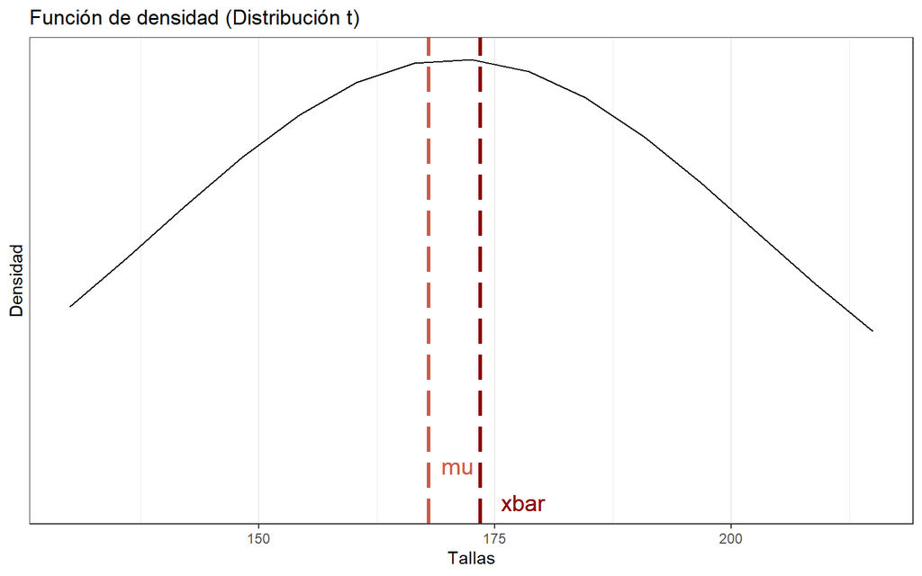

```r
# Grafico
grafico_densidad = ggplot(data = data.frame(x = c(130, 215)), aes(x)) +
  stat_function(fun = dt, n = 15, args = list(x =168, df = 14)) + ylab("") +
  scale_y_continuous(breaks = NULL) + xlab("Tallas") + ylab("Densidad") + ggtitle("Función de densidad (Distribución t)") + theme_bw() +
  geom_vline(xintercept = 173.47,cex=1.2,colour ="darkred",linetype="longdash") + geom_text(aes(x=178, label="xbar", y=0.0), colour ="darkred",size=5) + geom_vline(xintercept = 168,cex=1.2,colour ="coral3",linetype="longdash") + geom_text(aes(x=171, label="mu", y=0.001), colour ="coral3",size=5)

grafico_densidad
```

### **b) Calculo de t:**

```r
# Datos
mu=168
s = 7.36
x_bar=173.47
n=15

# Normalización
t = (x_bar-mu)/(s/sqrt(n))

# Confianza
alfa = 0.05
confianza = 1-alfa

t_alfa = qt(alfa,df = n-1)

t
```

```
## [1] 2.878426
```

```r
t_alfa
```

```
## [1] -1.76131
```

### **c) Grafica de lo obtenido y respuesta final:**

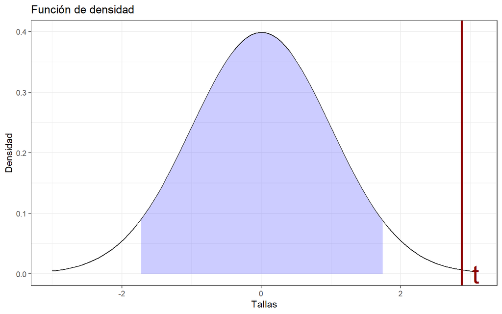

```r
# Grafico
dnorm_limit <- function(x) {
    y <- dnorm(x)
    y[x < t_alfa  |  x > -t_alfa] <- NA
    return(y)
}

# ggplot()
grafico_densidad = ggplot(data.frame(x = c(-3, 3)), aes(x = x)) +
  stat_function(fun = dnorm_limit, geom = "area", fill = "blue", alpha = 0.2) +  stat_function(fun = dnorm) +
  xlab("Tallas") + ylab("Densidad") + ggtitle("Función de densidad") +
  theme_bw() + geom_vline(xintercept = (x_bar-mu)/(s/sqrt(n)),cex=1.2,colour ="darkred") +
  geom_text(aes(x=(x_bar-mu)/(s/sqrt(n))+0.2, label="t", y=0.0), colour ="darkred",size=10)

plot(grafico_densidad)
```

## **Parte III: Ejemplo de uso para la prueba chi para varianza con dos colas:**

*“Un fabricante de baterías garantiza que su producto dura en promedio 2,5 años con una desviación estándar de 0,8 años. Si se toma una muestra aleatoria de 8 baterías y resultó que tiene una media muestral de 2,8 y una desviación estandar tipica muestral de 1,2, con la evidencia tomada ¿tiene razón el fabricante respecto a la desviación estándar poblacional? Utilice un nivel de significancia de 0,01.”*

### **a) Graficando la distribución de probabildad y declaración de hipótesis:**

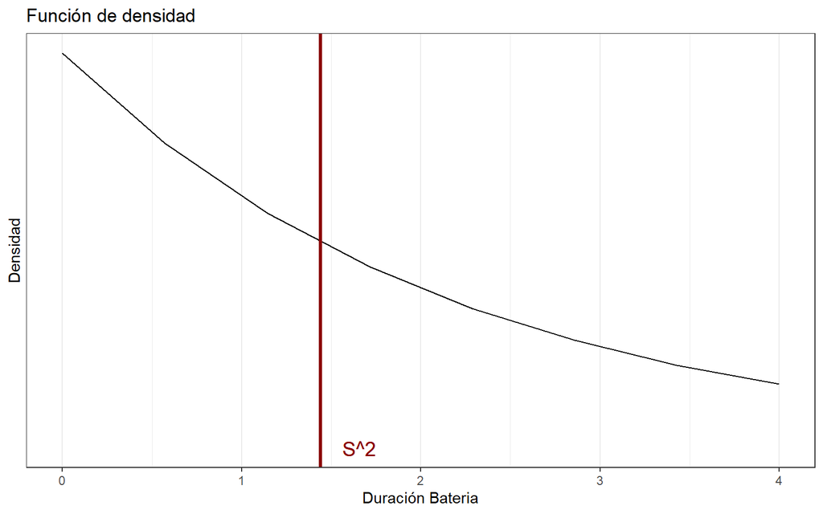

```r
# Grafico
grafico_densidad = ggplot(data = data.frame(x = c(0, 4)), aes(x)) +
  stat_function(fun = dchisq, n = 8, args = list(x =0.64, df = 7)) + ylab("") +
  scale_y_continuous(breaks = NULL) + xlab("Duración Bateria") + ylab("Densidad") + ggtitle("Función de densidad") + theme_bw() +
  geom_vline(xintercept = 1.44,cex=1.2,colour ="darkred") + geom_text(aes(x=1.66, label="S^2", y=0.0), colour ="darkred",size=5)

grafico_densidad
```

### **b) Calculo de chi y conclusión final:**

```r
# Datos
sigma2=0.64
n = 8
s2=1.44


# Normalización
chi = (n-1)*s2/(sigma2) # Calculo de la prueba

#Confianza
alfa = 0.01 # Nivel de significancia
confianza = 1-alfa

chi_alfa = qchisq(confianza,df = n-1) # Calculo de chi considerando el nivel de significancia

chi
```

```
## [1] 15.75
```

```r
chi_alfa
```

```
## [1] 18.47531
```

## **Parte IV: Ejemplo de bondad de ajuste Chi cuadrado, utilizando el conjunto de datos Iris**

Imaginemos que recolectamos rosas y encontramos que 50 eran de la especie setosa, 35 de la especie versicolor y 20 de la especie virginica. Suponga que un artículo científicoindica que en la región donde recopiló las rosas, la proporción de rosas setosa, versicolor y virginica es 3:2:1. ¿Hay alguna diferencia significativa entre las proporciones observadas y las proporciones esperadas?

### **a) Definicion de la hipótesis y realización de tablas:**

- **La hipótesis nula es:**
  $$H_0: \chi_0^2 < \chi_k^2$$
- **La hipótesis alternativa es:**
  $$H_0: \chi_0^2 > \chi_k^2$$

```r
data = data.frame(iris) # Se toma el dataframe iris

# Tabla de frecuencia variables cualitativas
# Frecuencia
fi=c(50,35,20) # Frecuencia absoluta
fac=cumsum(fi)                           # Frecuencia acumulada
fri=as.numeric(fi/sum(fi))*100           # Frecuencia relativa
frac=cumsum(fri)                         # Frecuencia relativa acumulada
especie=c("SETOSA", "VERSICOLOR", "VIRGINICA")
  # Tabla
frecuencias_esp= data.frame(especie,fi,fac,fri=round(fri,2),frac=round(frac,2))
  # Visualización
knitr::kable(frecuencias_esp)
```

| especie | fi | fac | fri | frac |
| --- | --- | --- | --- | --- |
| SETOSA | 50 | 50 | 47.62 | 47.62 |
| VERSICOLOR | 35 | 85 | 33.33 | 80.95 |
| VIRGINICA | 20 | 105 | 19.05 | 100.00 |

Si lo anterior esta en una relación de 3:2:1, eso implica que tenemos:

```r
data = data.frame(iris) # Se toma el dataframe iris

# Tabla de frecuencia variables cualitativas
# Frecuencia
fi=c(52.5,35,17.5) # Frecuencia absoluta
fac=cumsum(fi)                           # Frecuencia acumulada
fri=as.numeric(fi/sum(fi))*100           # Frecuencia relativa
frac=cumsum(fri)                         # Frecuencia relativa acumulada
especie=c("SETOSA", "VERSICOLOR", "VIRGINICA")
  # Tabla
frecuencias_esp= data.frame(especie,fi,fac,fri=round(fri,2),frac=round(frac,2))
  # Visualización
knitr::kable(frecuencias_esp)
```

| especie | fi | fac | fri | frac |
| --- | --- | --- | --- | --- |
| SETOSA | 52.5 | 52.5 | 50.00 | 50.00 |
| VERSICOLOR | 35.0 | 87.5 | 33.33 | 83.33 |
| VIRGINICA | 17.5 | 105.0 | 16.67 | 100.00 |

### **b) Calculo de chi y conclusión:**

```r
chi = ((50-52.5)/52.5) + ((35-35)/35) + ((20-17.5)/17.5) # Calculo de chi
df = 2 # Grados de libertad
chi_square = qchisq(0.05, df, lower.tail = F) # Calculo de chi con los grados de libertad

chi
```

```
## [1] 0.0952381
```

```r
chi_square
```

```
## [1] 5.991465
```

Como el
$$\chi_0^2$$
es menor al chi
$$\chi_k^2$$
calculado a traves de los grados de libertad, la hipótesis nula no se rechaza. En otras palabras, las rosas no tienen diferencia de proporcion a la que se deberia encontrar, por lo que se tiene una proporción 3:2:1

$$\chi_0^2 < \chi_k^2$$

## **Parte V: Ejemplo de prueba de hipótesis en una proporción binomial, de una cola.**

*“En una muestra de 105 comercios seleccionados al azar de una zona, se observa que 27 de ellos han tenido pérdidas en este mes. Un analista económico de la zona establece que la proporción de comercios en la zona con pérdidas es igual o superior a 0.35. Contraste dicha hip´otesis a un nivel de significación del 5 %.”*

### **a) Declaración de hipótesis:**

- **La hipótesis nula es:**
  $$H_0: p \geq 0,35$$
- **La hipótesis alternativa es:**
  $$H_A: p < 0,35$$

### **b) Calculo de z y conclusión:**

```r
# Datos para la prueba
p_barra = 27/105
p_sub_zero = 0.35
n = 105

z = (p_barra - p_sub_zero) / (sqrt((p_sub_zero*(1-p_sub_zero))/n)) # Calculo de z

alfa = 0.05 # Nivel de significancia
confianza = 1-alfa
z_alfa = qnorm(alfa)

z
```

```
## [1] -1.994891
```

```r
z_alfa
```

```
## [1] -1.644854
```

**Por lo tanto, se rechaza la Hipótesis Nula y se acepta la Hipótesis Alternativa**
$$p <
0,35$$

## **Parte VI: ejemplo de prueba de hipótesis en el que aplique la prueba del signo.**

*“Hemos preguntado a 120 personas su opinión sobre el café de dos cafeterías: A y B, de la Ciudad de Buenos Aires. Se le solicita a las personas indicar cual de las dos cafeterias prefieren. De ellas, 50 prefierena la cafeteria A y los restante 70 prefieren a la cafeteria B. Considerando un nivel de significancia del 5% ¿se puede afirmar que ambos cafes son igualmente populares?”*

### **a) Declaración de Hipótesis:**

- **Hipótesis Nula: Ambos cafes son igual de populares**
- **Hipótesis Alternativa: Un cafe es mas popular que otro**

### **b) Calculo de la prueba de signo y conclusión:**

```r
binom.test(50,120) # Calculo de la prueba de signo
```

```
##
##  Exact binomial test
##
## data:  50 and 120
## number of successes = 50, number of trials = 120, p-value = 0.08241
## alternative hypothesis: true probability of success is not equal to 0.5
## 95 percent confidence interval:
##  0.3273677 0.5101784
## sample estimates:
## probability of success
##              0.4166667
```

**Como el p-value de la prueba da 0.08241, siendo un valor mayor a 0.05, entonces estamos dentro del intervalo de confianza y por lo tanto, se acepta la Hipótesis Nula. Ambos cafes son igual de populares.**

## **Parte VII: ejemplo de prueba de hipótesis para la prueba de Wilcoxon para una muestra.**

Se tiene una muestra de peso de gatos. ¿La mediana del peso de estos gatos, difiere de 5 kg? Considere un nivel de significancia del 5%

### **a) Tabla de la muestra y declaración de hipótesis**

```r
# Tabla de frecuencia variables cualitativas
# Frecuencia
Pesos =c(3.2, 2.4, 3.6, 3.5, 4.2, 4.9) # Frecuencia absoluta
Gatos =c("Gato 1", "Gato 2", "Gato 3", "Gato 4", "Gato 5", "Gato 6")
  # Tabla
frecuencias_esp= data.frame(Gatos,Pesos)
  # Visualización
knitr::kable(frecuencias_esp)
```

| Gatos | Pesos |
| --- | --- |
| Gato 1 | 3.2 |
| Gato 2 | 2.4 |
| Gato 3 | 3.6 |
| Gato 4 | 3.5 |
| Gato 5 | 4.2 |
| Gato 6 | 4.9 |

- **Hipótesis Nula: La mediana de los gatos no difiere de 5 kg**
- **Hipótesis Alternativa: La mediana de los gatos difiere de 5 kg**

### **b) Calculo de la prueba de Wilcoxon y conclusión:**

```r
res <- wilcox.test(Pesos, mu = 5, conf.int = 0.95) # Calculo de la prueba

res
```

```
##
##  Wilcoxon signed rank exact test
##
## data:  Pesos
## V = 0, p-value = 0.03125
## alternative hypothesis: true location is not equal to 5
## 95 percent confidence interval:
##  2.4 4.9
## sample estimates:
## (pseudo)median
##            3.6
```

**Con un nivel de signifancia del 5% se tiene que la mediana de los gatos difiere de 5kg. Por lo tanto, se rechaza la Hipótesis Nula y se acepta la Hipótesis Alternativa**

## **Referencias**

**[1]** Vargas, M. (2012). “Ejemplos Resueltos Tema 4”. Guía de estudio Online. Recuperado de: https://www.ugr.es/~mvargas/Infe2.pdf

**[2]** Universidad Nueva Granada. (Año desconocido). “Ejemplo de hipótesis para la varianza”. Articulo online. Recuperado de: http://virtual.umng.edu.co/distancia/ecosistema/ovas/ingenieria_civil/probabilidad_y_estadistica/unidad_5/medios/documentacion/p12h8.php

**[3]** UCI - Machine Learning Repository. (Año desconocido). “Iris Data Set”. Repositorio online. Recuperado de: https://archive.ics.uci.edu/ml/datasets/iris

**[4]** Dietrichson, A. (2019). “Métodos Cuantitativos”. Libro Online. Recuperado de: https://bookdown.org/dietrichson/metodos-cuantitativos/prueba-de-signos.html

**[5]** Amat, J. (2016). “Prueba de los rangos con signo de Wilcoxon”. Documentación Online. Recuperado de: https://www.cienciadedatos.net/documentos/18_prueba_de_los_rangos_con_signo_de_wilcoxon

**[6]** Villalobos, M. Giglio, J. Villanueva, M. (2022). “Estadística Aplicada”. Material de clases. Recuperado de: https://uvirtual.usach.cl/moodle/